# Preliminary results for EFB650

This document walks through the code & analysis I’ve done using the iTree data Jake downloaded. The tl;dr is that our model is significantly supported, it seems like canopy cover & basal area are associated with lower temperatures while impervious surfaces are associated with higher temperatures.

First off, we’ll load our libraries that we’re using today:

```r
library(dplyr)
library(tidyr)
library(kableExtra)
library(lme4)
```

```r
library(ggplot2)
```

I’ve got all the CSVs that Jake downloaded stored in a folder called “rawdata”. Today I’m just going to use files with `HiRes` in the name, because I don’t fully understand the difference between the two datasets and how much we’d be able to combine them.

The first step, then, is to load all of our `HiRes` CSV files into a single data frame:

```r
# Get a list of all the files in rawdata with HiRes in the name
tables <- grep("2011",
               paste0("rawdata/", list.files("rawdata")),
               value = TRUE)

# Extract the town/county names from the HiRes files
# We'll call these "city" values, but some of them are county level ("Nassau")
names(tables) <- gsub("_",
                      "",
                      gsub("2011\\.csv$",
                           "",
                           regmatches(tables,
                                      regexpr("[a-zA-z0-9\\.]*$",
                                              tables)
                                      )
                           )
                      )
# Read each of the tables in as separate data frames
tables <- lapply(tables, read.csv)

for (i in seq_along(tables)) {
  # Add a column named "city" with the values we just calculated
  tables[[i]] <- cbind(tables[[i]],
                       city = names(tables)[[i]])
}

# Combine them all into a single table
tables <- dplyr::as_tibble(do.call(rbind, tables))
```

Now that we have our data read in, it’s time for us to cut down our variables somewhat. We’ll assign new names to the variables we want, calulate a new area-weighted variable from the BA metric, and drop the variables we aren’t going to use. We’re also going to scale all our predictors using the formula $\frac{(x-\bar{x})}{\sigma{}}$ to make the directional impact of our variables make more sense – our BA coefficients get crazy without the rescaling.

```r
cur_out <- tables %>%
  transmute(city = city,
            temp_diff = Land.Surface.Temperature.Difference..Landsat.scene.difference...celsius.,
            canopy_per = Canopy..percent.,
            impervious_per = Impervious..percent.,
            vacant_per = Vacant.Percent..percent.,
            developed_open_per = Developed..Open.Space..percent.,
            developed_high_per = Developed..High.Intensity..percent.,
            developed_med_per = Developed..Medium.Intensity..percent.,
            developed_low_per = Developed..Low.Intensity..percent.,
            # Make this unitless - m2/m2 - for comparison's sake
            ba_per = (Total.Basal.Area..feet.squared. / 10.764) / Area..meters.squared.) %>%
  # drop obvious placeholder value
  filter(temp_diff > -9999) %>%
  # rescale predictors
  mutate(across(-c("city", "temp_diff"), scale))
```

Alright, now onto our modeling. First off, let’s define some model formulas we want to use:

```r
model_formulas <- c(
  "Null Model" = temp_diff ~ 1 + (1 | city),
  "Canopy Cover" = temp_diff ~ canopy_per + (1 | city),
  "Canopy Cover and Basal Area" = temp_diff ~ canopy_per * ba_per + (1 | city),
  "Canopy Cover, Basal Area, Impervious Surfaces, and Vacant Lands" = temp_diff ~ canopy_per * ba_per + impervious_per + vacant_per + (1 | city),
  "Canopy Cover, Basal Area and Impervious Surfaces" = temp_diff ~ canopy_per * ba_per + impervious_per + (1 | city)
)
```

With our models defined like that, it takes one line of code to fit our models:

```r
model_fits <- lapply(model_formulas, function(x) lme4::lmer(x, cur_out))
```

Now let’s build our reporting table. We’re going to pull out our model coefficients and put them in a table, and then attach AIC metrics which will be our main way of comparing model formulas:

```r
model_glance <- do.call(bind_rows,
                        mapply(function(nm, md) cbind(model = nm,
                                                      broom.mixed::glance(md)),
                               names(model_fits),
                               model_fits,
                               SIMPLIFY = FALSE))
model_tidy <- do.call(bind_rows,
                        mapply(function(nm, md) cbind(model = nm,
                                                      broom.mixed::tidy(md)),
                               names(model_fits),
                               model_fits,
                               SIMPLIFY = FALSE))
model_coef <- model_tidy %>%
  filter(group != "Residual" | is.na(group)) %>%
  mutate(term = stringr::str_replace_all(term,
                                         c("sd__\\(Intercept\\)" = "City",
                                           "\\(Intercept\\)" = "Intercept",
                                           ":" = " : ",
                                           "canopy_per" = "Canopy Coverage",
                                           "ba_per" = "BA Coverage",
                                           "impervious_per" = "Impervious Surfaces",
                                           "vacant_per" = "Vacant Lands")),
         out = paste0(estimate = scales::number(estimate, 0.001),
                      " (",
                      std.error = scales::number(std.error, 0.001),
                      ")")) %>%
  select(-effect, -group, -statistic, -estimate, -std.error) %>%
  pivot_wider(names_from = term, values_from = out) %>%
  mutate(City = substr(City, 1, 5))

model_glance$dAIC <- model_glance$AIC - model_glance[which(model_glance$AIC == min(model_glance$AIC)), ]$AIC

model_table <- model_glance %>%
  mutate(relLike = exp(-0.5 * dAIC)) %>%
  mutate(AkaWeight = relLike / sum(relLike)) %>%
  arrange(AIC) %>%
  mutate(CumuWeight = cumsum(AkaWeight),
         AkaWeight = scales::number(AkaWeight, 0.001),
         CumuWeight = scales::number(CumuWeight, 0.001)) %>%
  select(model, dAIC, AkaWeight, CumuWeight) %>%
  full_join(model_coef, by = "model") %>%
  select(-contains(":"), everything(), contains(":")) %>%
  mutate(across(everything(), ~ ifelse(is.na(.x), "", .x))) %>%
  mutate(dAIC = scales::number(dAIC, 0.001)) %>%
  rename(Model = model,
         "Akaike Weight" = AkaWeight,
         "Cumulative Weight" = CumuWeight)
```

So after all that work, we’re left with a clean table with our model results:

```r
model_table %>%
  kableExtra::kable() %>%
  kableExtra::kable_styling(font_size = 10)
```

| Model | dAIC | Akaike Weight | Cumulative Weight | Intercept | City | Canopy Coverage | BA Coverage | Impervious Surfaces | Vacant Lands | Canopy Coverage : BA Coverage |
| --- | --- | --- | --- | --- | --- | --- | --- | --- | --- | --- |
| Canopy Cover, Basal Area, Impervious Surfaces, and Vacant Lands | 0.000 | 1.000 | 1.000 | 4.850 (0.800) | 2.649 | -0.088 (0.055) | -1.422 (0.092) | 1.945 (0.046) | -0.261 (0.023) | 0.352 (0.037) |
| Canopy Cover, Basal Area and Impervious Surfaces | 121.732 | 0.000 | 1.000 | 4.831 (0.774) | 2.565 | -0.114 (0.056) | -1.392 (0.094) | 1.799 (0.045) |  | 0.294 (0.038) |
| Canopy Cover and Basal Area | 1 485.620 | 0.000 | 1.000 | 4.474 (0.779) | 2.579 | -1.257 (0.055) | -2.255 (0.106) |  |  | 0.714 (0.042) |
| Canopy Cover | 3 149.017 | 0.000 | 1.000 | 4.782 (0.703) | 2.329 | -2.225 (0.034) |  |  |  |  |
| Null Model | 11 128.142 | 0.000 | 1.000 | 4.212 (0.486) | 1.607 |  |  |  |  |  |

If you’ve never worked with AIC before, a crash course in interpreting the above table: dAIC is a measure of distance from the best model – our best model has dAIC 0. Models with dAIC < 4 are about the same quality of fit – so in our case, our best model is a better fit than any other model. Additionally, our best model is super distant from the null model, meaning it actually explains a good amount of the variance in the data!

Now, with interaction terms, it’s hard to interpret our coefficients directly. It’s easier to separate out each of our coefficients into a separate model to see their relationship with temperature:

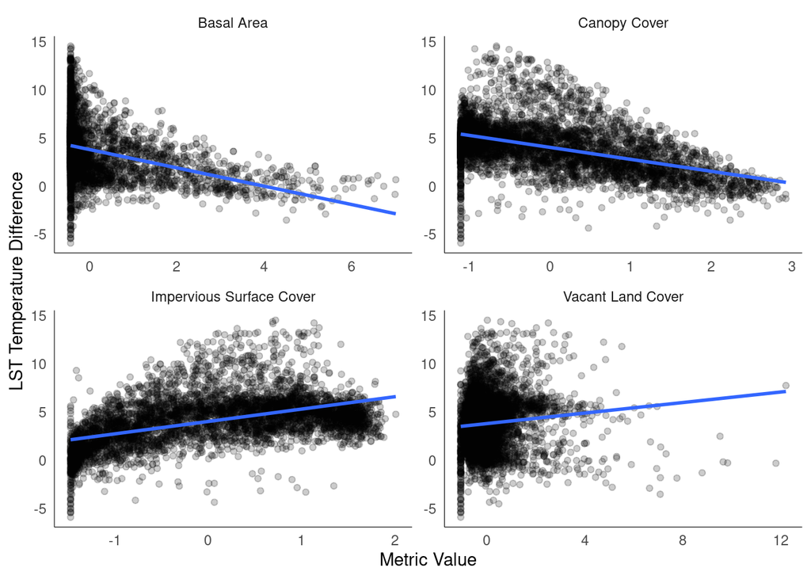

```r
cur_out %>%
  select(city, temp_diff, canopy_per, impervious_per, vacant_per, ba_per) %>%
  rename("Basal Area" = ba_per,
         "Canopy Cover" = canopy_per,
         "Impervious Surface Cover" = impervious_per,
         "Vacant Land Cover" = vacant_per) %>%
  pivot_longer(cols = -c(city, temp_diff)) %>%
  drop_na() %>%
  ggplot(aes(value, temp_diff)) +
  geom_point(alpha = 0.2) +
  geom_smooth(se = FALSE, method = "lm") +
  facet_wrap(~ name, scales = "free") +
  theme_minimal() %+replace%
  theme(panel.grid = element_blank(),
        axis.line = element_line(size = 0.2)) +
  labs(x = "Metric Value",
       y = "LST Temperature Difference")
```

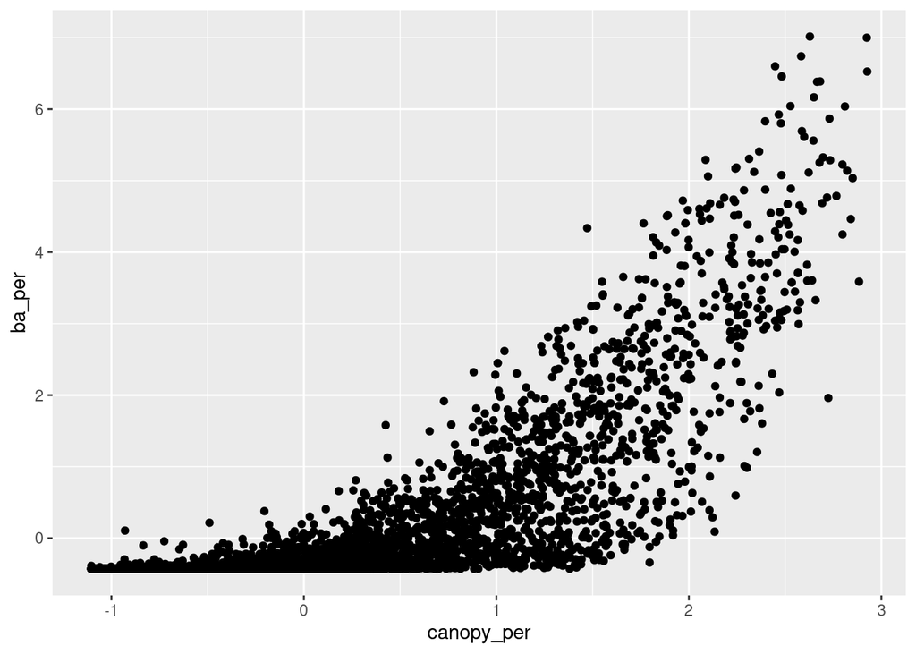

```r
ggplot(cur_out, aes(canopy_per, ba_per)) +
  geom_point()
```

Yeah, so canopy cover has an exponential relationship to basal area. That means that higher canopy % is still associated with lower temperatures, just that the model is using it to offset the increase in BA.

Alright, so that’s it from me for right now. It’d be useful to me for us to meet again and talk over what we want to include in our final report!